# assignment5_nn_withnumpy

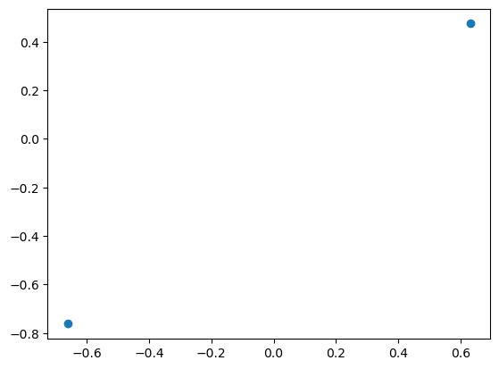

```python
from sklearn.datasets import make_gaussian_quantiles
import matplotlib.pyplot as plt

samples = 2
def load_extra_datasets(N):
    gaussian_quantiles = make_gaussian_quantiles(mean=None,
                                                 cov=0.7,
                                                 n_samples=N,
                                                 n_features=2,
                                                 n_classes=2,
                                                 shuffle=True,
                                                 random_state=None)
    return  gaussian_quantiles

gaussian_quantiles = load_extra_datasets(samples)

X, Y = gaussian_quantiles

X, Y = X.T, Y.reshape(1, Y.shape[0])

#print(Y)
# Visualize the data
plt.scatter(X[0, :], X[1, :]) #, c=Y, s=40);
plt.show()
```

## the samples = 2 can be replaced with samples = n, for example n = 200

```python
X
```

```
array([[-0.66057139,  0.63125632],
       [-0.76239789,  0.47472691]])
```

```python
Y
```

```
array([[1, 0]])
```

```python
n_x = X.shape[0] # size of input layer`
n_h = 4
n_y = Y.shape[0] # size of output layer

print(n_x, n_y)
```

```
2 1
```

```python
import numpy as np

W1 = np.random.randn(n_h,n_x) * 0.01
b1 = np.zeros(shape=(n_h, 1))
W2 = np.random.randn(n_y,n_h) * 0.01
b2 = np.zeros(shape=(n_y, 1))

print("W1\n", W1)
print("b1\n", b1)
print("W2\n", W2)
print("b2\n", b2)
```

```
W1
 [[-0.00976817  0.00619804]
 [ 0.01054119  0.02090506]
 [-0.01127246  0.01532462]
 [ 0.0157391  -0.0043558 ]]
b1
 [[0.]
 [0.]
 [0.]
 [0.]]
W2
 [[ 0.00891995 -0.00452441  0.00972938  0.01513667]]
b2
 [[0.]]
```

```python
def sigmoid(x):
    return 1 / (1 + np.e ** -x)

total_cost = -9999
```

```python
# Implement Forward Propagation to calculate A2 (probabilities)
Z1 = np.dot(W1,X) + b1
A1 = np.tanh(Z1)
Z2 = np.dot(W2,A1) + b2
A2 = sigmoid(Z2) # Final output prediction

print(A2)
```

```
[[0.49999267 0.50000422]]
```

```python
samples
```

```
2
```

```python
# Compute the cross-entropy cost
old_total_cost = total_cost
cost_function = np.multiply(np.log(A2), Y) + np.multiply((1 - Y), np.log(1 - A2)) #J(theta)
total_cost = -np.sum(cost_function) / samples

print("cost=", total_cost)
print("cost delta=", np.subtract(total_cost, old_total_cost))
```

```
cost= 0.6931587320075032
cost delta= 9999.693158732007
```

```python
cost_function
```

```
array([[-0.69316184, -0.69315562]])
```

```python
print(Z1.shape)
print(A1.shape)
print(Z2.shape)
print(A2.shape)
print(cost_function.shape)
```

```
(4, 2)
(4, 2)
(1, 2)
(1, 2)
(1, 2)
```

## Now begin our back propagation

```python
dJdZ2 = A2 - Y
dJdW2 = (1 / samples) * np.dot(dJdZ2, A1.T)
dJdb2 = (1 / samples) * np.sum(dJdZ2, axis=1, keepdims=True)

# since activation function is tanh(Z1) = A1, for reaching A1 from Z1
# first derivative of d/dz tanh(z) = 1 - tanh(z) ^ 2 = 1 - A1 ^ 2
dJdZ1 = np.multiply(np.dot(W2.T, dJdZ2), 1 - np.power(A1, 2))
dJdW1 = (1 / samples) * np.dot(dJdZ1, X.T)
dJdb1 = (1 / samples) * np.sum(dJdZ1, axis=1, keepdims=True)

print("dJdZ2=", dJdZ2)
print("dJdW2=", dJdW2)
print("dJdb2=", dJdb2)
print("dJdW1=", dJdW1)
print("dJdb1=", dJdb1)
```

```
dJdZ2= [[-0.50000733  0.50000422]]
dJdW2= [[-0.00123777  0.00986863  0.00109911  0.00373586]]
dJdb2= [[-1.55602137e-06]]
dJdW1= [[ 0.00288077  0.00275879]
 [-0.00146062 -0.00139873]
 [ 0.00314218  0.00300912]
 [ 0.00488828  0.00468129]]
dJdb1= [[-3.04036712e-08]
 [-2.75162474e-07]
 [ 2.84692805e-08]
 [-6.83153962e-08]]
```

```python
learning_rate = 0.01
b2_old = b2
print("b2 before=", b2_old)

W1 = W1 - learning_rate * dJdW1
b1 = b1 - learning_rate * dJdb1
W2 = W2 - learning_rate * dJdW2
b2 = b2 - learning_rate * dJdb2

print("b2 after=", b2)

print("delta change=", np.subtract(b2, b2_old))
```

```
b2 before= [[0.]]
b2 after= [[1.55602137e-08]]
delta change= [[1.55602137e-08]]
```

## 3. Neural Network using numpy:

1. Redo the example code in the NN using numpy notebook and recalculate the delta change in weight b2 for
   1. different learning rates of 0.0001, 0.01 and 1
   2. and for 10 iterations
2. What can you conclude about the effect of the learning rate on the delta change in weight b2?

### We define a function compute_delta_b2(learning_rate) that computes the delta change in weight b2 for a given learning rate.

### We iterate over each learning rate and for each learning rate, perform the computation for the specified number of iterations.

### We print the delta change in weight b2 for each iteration and learning rate.

X, Y fixed

```python
# Define the function to compute delta change in weight b2
def compute_delta_b2(learning_rate, W1, b1, W2, b2, X, Y, iterations):
    for _ in range(iterations):

        Z1 = np.dot(W1,X) + b1
        A1 = np.tanh(Z1)
        Z2 = np.dot(W2,A1) + b2
        A2 = sigmoid(Z2) # Final output prediction

        dJdZ2 = A2 - Y
        dJdW2 = (1 / samples) * np.dot(dJdZ2, A1.T)
        dJdb2 = (1 / samples) * np.sum(dJdZ2, axis=1, keepdims=True)

        dJdZ1 = np.multiply(np.dot(W2.T, dJdZ2), 1 - np.power(A1, 2))
        dJdW1 = (1 / samples) * np.dot(dJdZ1, X.T)
        dJdb1 = (1 / samples) * np.sum(dJdZ1, axis=1, keepdims=True)

        b2_old = b2

        W2 = W2 - learning_rate * dJdW2
        b2 = b2 - learning_rate * dJdb2
        W1 = W1 - learning_rate * dJdW1
        b1 = b1 - learning_rate * dJdb1
        # the new values of W2 and B2 do not influence the update of W1 and B1 within the same training iteration
        # because all updates use the gradients calculated from the state of the network at the beginning of the backward pass.

        delta_change = np.subtract(b2, b2_old)
        print("Delta Change in Weight b2:", delta_change, "updated b2:", b2)

# Initialize weights and biases
W1 = np.random.randn(n_h,n_x) * 0.01
b1 = np.zeros(shape=(n_h, 1))
W2 = np.random.randn(n_y,n_h) * 0.01
b2 = np.zeros(shape=(n_y, 1))

# Learning rates to test
learning_rates = [0.0001, 0.01, 1]
iterations = 10

# Perform computation for each learning rate and print the results
for lr in learning_rates:
    print(f"\nLearning Rate: {lr}\n")
    compute_delta_b2(lr, W1, b1, W2, b2, X, Y, iterations)
```

```
Learning Rate: 0.0001

Delta Change in Weight b2: [[-2.06450114e-10]] updated b2: [[-2.06450114e-10]]
Delta Change in Weight b2: [[-2.06548777e-10]] updated b2: [[-4.12998892e-10]]
Delta Change in Weight b2: [[-2.06647442e-10]] updated b2: [[-6.19646334e-10]]
Delta Change in Weight b2: [[-2.0674611e-10]] updated b2: [[-8.26392444e-10]]
Delta Change in Weight b2: [[-2.06844779e-10]] updated b2: [[-1.03323722e-09]]
Delta Change in Weight b2: [[-2.06943451e-10]] updated b2: [[-1.24018067e-09]]
Delta Change in Weight b2: [[-2.07042126e-10]] updated b2: [[-1.4472228e-09]]
Delta Change in Weight b2: [[-2.07140802e-10]] updated b2: [[-1.6543636e-09]]
Delta Change in Weight b2: [[-2.07239481e-10]] updated b2: [[-1.86160308e-09]]
Delta Change in Weight b2: [[-2.07338162e-10]] updated b2: [[-2.06894125e-09]]

Learning Rate: 0.01

Delta Change in Weight b2: [[-2.06450114e-08]] updated b2: [[-2.06450114e-08]]
Delta Change in Weight b2: [[-2.16330771e-08]] updated b2: [[-4.22780885e-08]]
Delta Change in Weight b2: [[-2.26234838e-08]] updated b2: [[-6.49015724e-08]]
Delta Change in Weight b2: [[-2.36163187e-08]] updated b2: [[-8.85178911e-08]]
Delta Change in Weight b2: [[-2.46116688e-08]] updated b2: [[-1.1312956e-07]]
Delta Change in Weight b2: [[-2.56096216e-08]] updated b2: [[-1.38739181e-07]]
Delta Change in Weight b2: [[-2.66102646e-08]] updated b2: [[-1.65349446e-07]]
Delta Change in Weight b2: [[-2.76136859e-08]] updated b2: [[-1.92963132e-07]]
Delta Change in Weight b2: [[-2.86199736e-08]] updated b2: [[-2.21583106e-07]]
Delta Change in Weight b2: [[-2.9629216e-08]] updated b2: [[-2.51212322e-07]]

Learning Rate: 1

Delta Change in Weight b2: [[-2.06450114e-06]] updated b2: [[-2.06450114e-06]]
Delta Change in Weight b2: [[-1.33818084e-05]] updated b2: [[-1.54463096e-05]]
Delta Change in Weight b2: [[-3.16895323e-05]] updated b2: [[-4.71358419e-05]]
Delta Change in Weight b2: [[-6.93006726e-05]] updated b2: [[-0.00011644]]
Delta Change in Weight b2: [[-0.00014861]] updated b2: [[-0.00026505]]
Delta Change in Weight b2: [[-0.00031366]] updated b2: [[-0.00057871]]
Delta Change in Weight b2: [[-0.00064775]] updated b2: [[-0.00122646]]
Delta Change in Weight b2: [[-0.00129013]] updated b2: [[-0.00251659]]
Delta Change in Weight b2: [[-0.00240768]] updated b2: [[-0.00492427]]
Delta Change in Weight b2: [[-0.00400566]] updated b2: [[-0.00892994]]
```

## dJdZ2 = A2 - Y

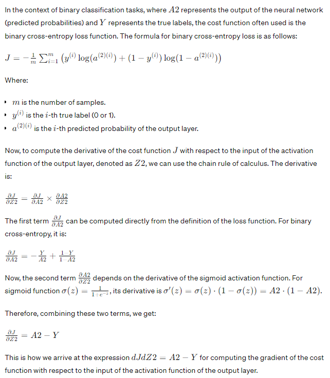

## dJdW2 = (1 / samples) * np.dot(dJdZ2, A1.T)

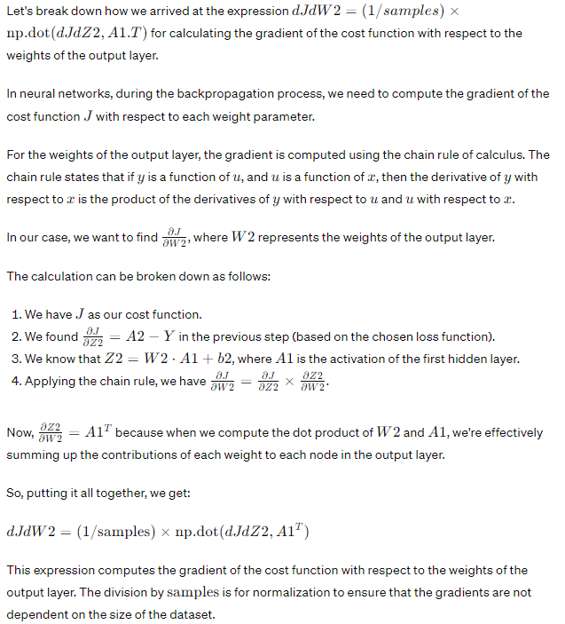

## dJdb2 = (1 / samples) * np.sum(dJdZ2, axis=1, keepdims=True)

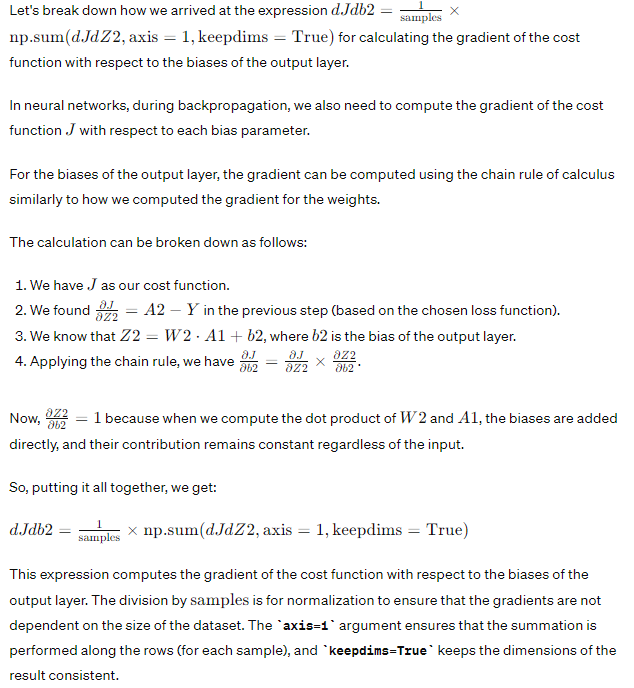

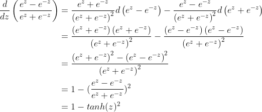

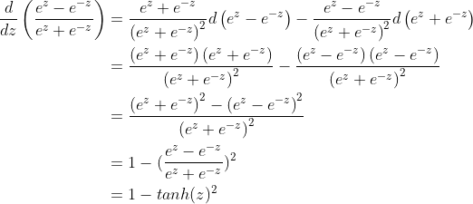

## dJdZ1 = np.multiply(np.dot(W2.T, dJdZ2), 1 - np.power(A1, 2))

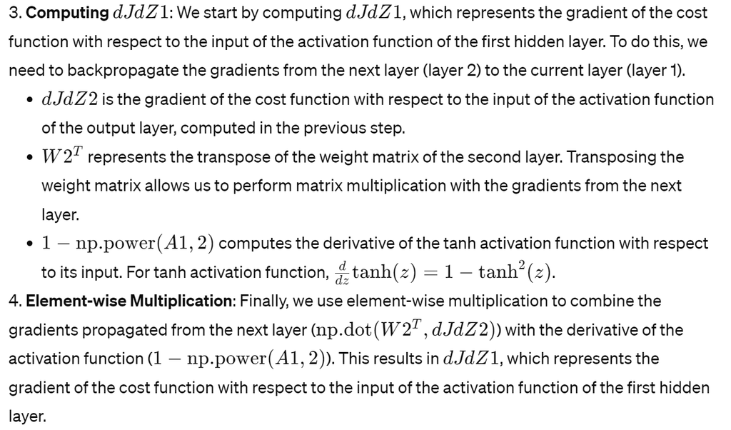

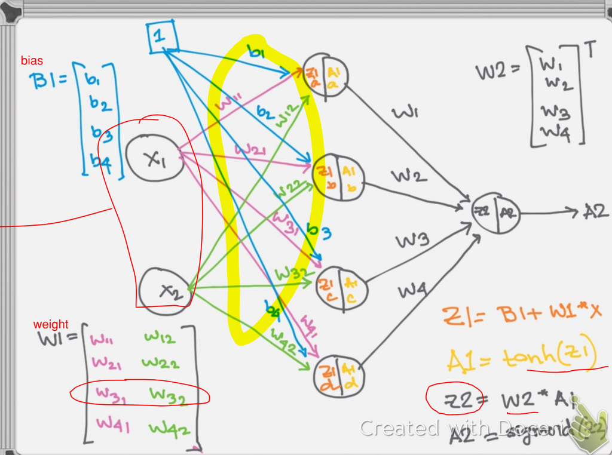

[figure not shown]

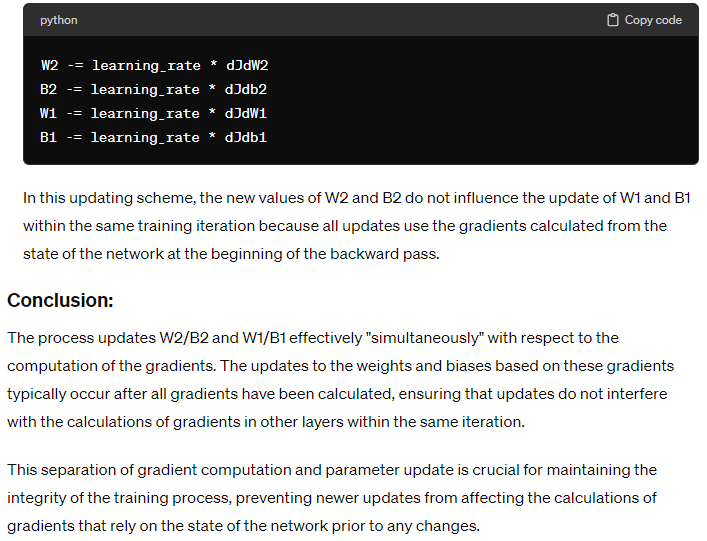